# Mountain Yellow-legged Frog Population Assesment

Conner Smith

1/13/2022

## **Overview**

This task explores the occurrence of endangered Mountain Yellow-legged frogs in lakes throughout the Sierra Nevada region. Counts are drawn from amphibian abundance data recorded by the Sierra Lakes Inventory Project which ran from 1995-2002 and has supported research and management of Sierra Nevada aquatic ecosystems and their terrestrial interfaces.

```r
knitr::opts_chunk$set(echo = TRUE, message = FALSE, warning = FALSE)

library(tidyverse)
library(here)
library(cowplot)
library(patchwork)
library(lubridate)
```

## **Analysis**

This analysis filters the larger dataset to gather the counts for Moutain Yellow-legged frogs by life stage (Adult, Sub-adult, or Tadpole) across the region as a whole. It also includes the total counts (irrespective of age but excluding tadpoles) for the five lakes with the highest recorded numbers of this species and presents the results ina combined visualization (**Figure 1**).

```r
# Read in xlsx file with 'read_xlsx

frogs <- readxl::read_xlsx(here("data", "sierra_amphibians.xlsx"))
```

```r
# Filter for Mountain Yellow-legged Frogs (Species code: RAMU), excluding egg life stage (code: EggMass) and group by year and lifestage.

frogs_clean <- frogs %>%
  filter(amphibian_species == 'RAMU',
         amphibian_life_stage != 'EggMass') %>%
  mutate(date = ymd(survey_date)) %>%
  mutate(year = year(date)) %>%
  select(year, amphibian_species,
         amphibian_life_stage, amphibian_number, lake_id, amphibian_location) %>%
  group_by(year, amphibian_life_stage)


frogs_summary <- frogs_clean %>%
  summarize(count = sum(amphibian_number, na.rm = TRUE))
```

```r
# Create a column graph of the above data frame, but do not incldue this graph in the knitted document

years <- ggplot(data = frogs_summary, aes(x = year, y = count)) +
  geom_col(aes(fill = amphibian_life_stage),
           width = 0.75,
           position = "dodge",
           show.legend = TRUE) +
  scale_fill_manual(labels = c("Adult", "Sub-Adult", "Tadpole"),
                               values = c("yellowgreen",
                                          "seagreen3", "skyblue3")) +
  theme_bw() +
  labs(x = "Year", y = "Count", fill = 'Life Stage')
```

```r
# Create a second graph categorizing counts by the top five lakes

top_lakes <- frogs_clean %>%
  filter(amphibian_life_stage != 'Tadpole') %>%
  filter(amphibian_location == "in lake") %>%
  group_by(lake_id) %>%
  summarize(count = sum(amphibian_number)) %>%
  mutate(lake_id = as.character(lake_id)) %>%
  mutate(lake_id = paste("Lake", lake_id, sep = ' ')) %>%
  mutate(lake_id = fct_reorder(lake_id, count)) %>%
  slice_max(count, n = 5)

# Make the graph but do not show it in the knitted document

lakes <- ggplot(data = top_lakes, aes(x = reorder(lake_id, -count),
                                      y = count)) +
  geom_col(fill = "darkseagreen4",
           width = 0.5,
           show.legend = FALSE) +
  theme_bw() +
  labs(x = "Lake ID", y = "Count")
```

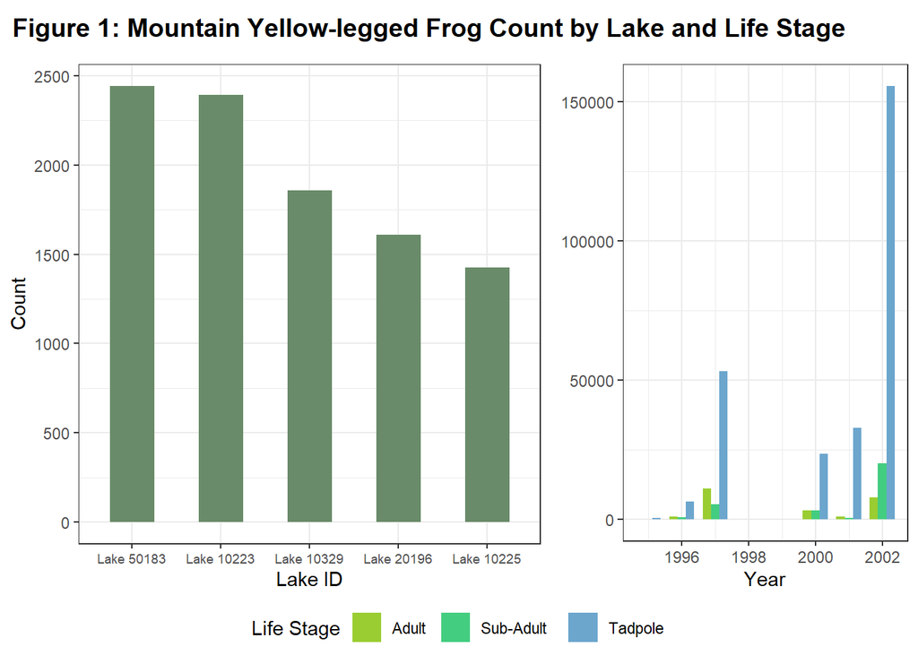

```r
# Combine the two figures using cowplot::plot_grid

title <- ggdraw() +
  draw_label(
    "Figure 1: Mountain Yellow-legged Frog Count by Lake and Life Stage",
    fontface = 'bold',
    x = 0,
    hjust = 0) +
  theme(plot.margin = margin(0, 0, 0, 7))


plots <- plot_grid(lakes + theme(axis.text.x = element_text(size = 7)),
                   years + theme(legend.position = "none",
                                 axis.title.y = element_blank()),
                   ncol = 2,
                   rel_widths = c(1.5, 1))

legend <- get_legend(years +
                       theme(legend.position = "bottom"))


plot_grid(title, plots, legend, ncol = 1,
          rel_heights = c(0.1, 1, 0.1))
```

**Figure 1:** *The left graph provides a count of observed Mountain Yellow-legged Frogs (combining adults and sub-adults) across the five lakes (by Lake ID) with the highest recorded counts. The graph on the right provides a count of observed Mountain Yellow-legged Frogs across all lakes by life stage and year between 1995 and 2002.*

## **Data Citation**

*Knapp, R.A., C. Pavelka, E.E. Hegeman, and T.C. Smith. 2020. The Sierra Lakes Inventory Project: Non-Native fish and community composition of lakes and ponds in the Sierra Nevada, California ver 2. Environmental Data Initiative. https://doi.org/10.6073/pasta/d835832d7fd00d9e4466e44eea87fab3*